# Garden Experiment Power Analysis

# Biomass

## Estimates of variation

Estimates of the total plant above-ground biomass (TAGB) for one year old tropical forest successional communities are scarce in the literature. From a comprehensive review by Martin, Newton, and Bullock (2013), where authors compiled data on TAGB from 607 secondary forest sites, we were able to extract only two estimates of TAGB for plant community after one year of regeneration since abandonment. TAGB for these two plots averaged at $\sim$ 12 Mg $\times$ ha $^{-1}$ (which gives 30 kg $\times$ 25 m$^{2}$ for experimental plot used in our study). However, these plots were restricted only to secondary succession after pasture abandonment, which may negatively affect initial biomass accumulation rates. Different study of wet tropical forest succession in gaps by Mascaro et al. (2005) reported average 78 $\pm$ 15 Mg $\times$ ha $^{-1}$ (195 kg $\times$ 25 m$^{2}$) TAGB after one year following hurricane disturbance. We expected that TAGB of a vegeatation regenerating after small slash-and-burn cultivation within a primary forest matrix should fall somewhere between the above rage. We believe that it value should be higher than during spontaneous succession in pastures, and at the same time lower than in forest gaps created by hurricanes. Moreover, by design we tried to minimise unpredicted differences in initial conditions for regeneration, which should keep the variation between and within blocks small. Therefore for the theoretical distribution of plant biomass in a 25 m$^2$ plots we safely assumed log-normal distribution with $\mu$ = 100 kg and $\sigma_{a}$ = $\sigma_{\varepsilon}$ = 10 kg (Fig.1) and effect size of 15 kg.

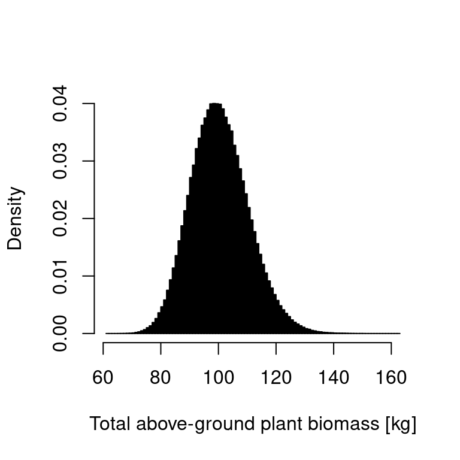

Figure 1. Histogram of expected values of total above-ground biomass (TAGB) of a one year old successional plant community at a 25 m$^2$ experimental plot. Densities follow the log-normal distribution with $\mu$ = 100 kg, and $\sigma$ = 10 kg.

## Randomization

With the above approximations of $\mu$, $\sigma^2_{a}$, $\sigma^2_{\varepsilon}$ and selected effect size we can now create a hypothetical dataset with an arbitrary number of blocks each having 6 experimental treatment (including control) and examine sample size necessary to obtain 80% statistical power.

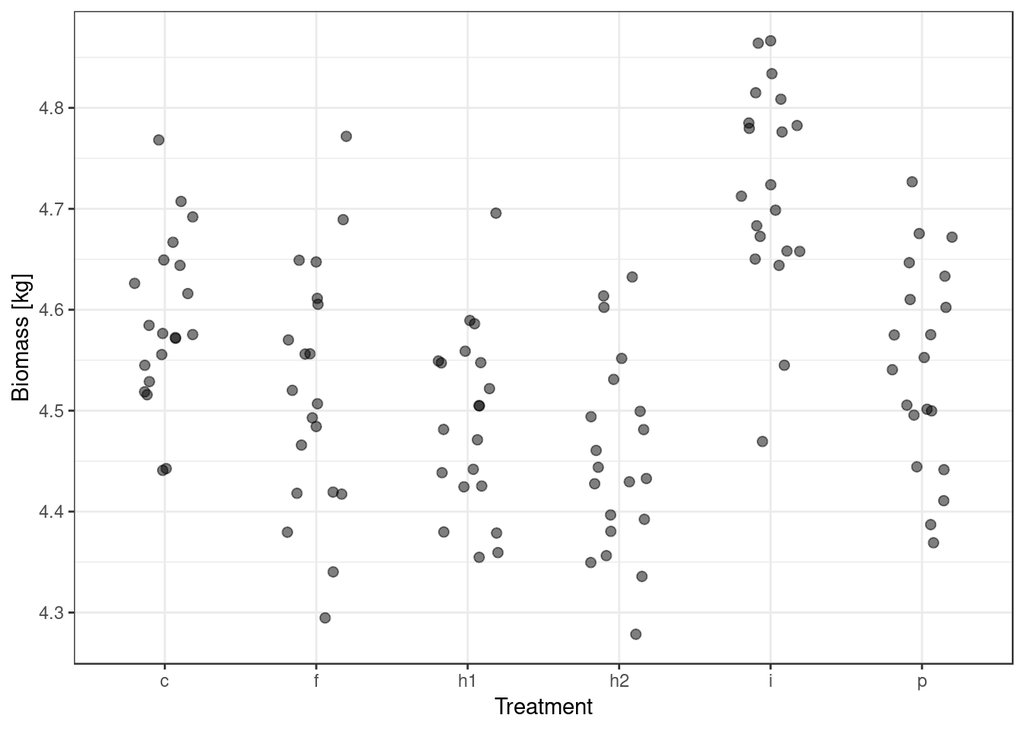

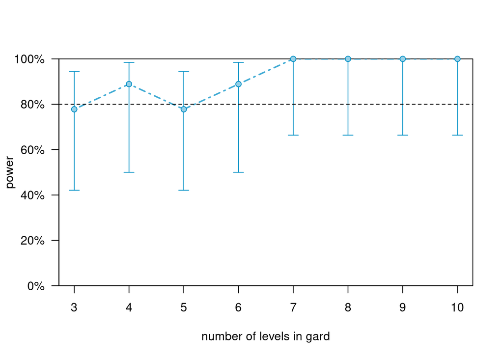

From this analysis we conclude that for the above assumptions we have 80% probability of detecting existing effects already with six experimental blocks.